# **데이터과학과소셜데이터분석 과제2**

## 경영학과 2017312717 나종진

## 필요한 라이브러리 import

```python
import pandas as pd
import matplotlib.pyplot as plt
%matplotlib inline
import seaborn as sns
import sklearn
from sklearn.linear_model import LinearRegression
```

## 데이터 가져오기(필요한 데이터를 가지고 오는 과정)

### 데이터 설명

ExchangeRates는 환율 데이터로 2016년 1월부터 2021년 6월까지 월단위로 구성. 원/미국달러, 원/위안, 원/일본엔, 원/유로 총 4가지가 있음.

CurrencyFutures은 통화선물데이터로 2016년 1월부터 2021년 6월까지 월단위로 구성. 미국달러선물, 일본엔선물, 유로선물, 위안선물 4가지 종류의 선물로 각각 계약수, 계약금액, 미결제약정이 있음.

아래 print결과를 통해 자세히 확인 가능.

```python
ExchangeRates = pd.read_csv('./ExchangeRates.csv', index_col=0, na_values=0 )
CurrencyFutures = pd.read_csv('./CurrencyFutures.csv', index_col=0, na_values=0, )
ExchangeRates = ExchangeRates.fillna(0)
CurrencyFutures = CurrencyFutures.fillna(0)
print(ExchangeRates)
print(CurrencyFutures)
```

```
        원/미국달러    원/위안  원/일본엔(100엔)     원/유로
날짜
201601  1208.4  182.78      1017.13  1322.17
201602  1235.4  189.00      1085.83  1348.32
201603  1153.5  177.69      1026.02  1307.43
201604  1143.9  175.95      1058.19  1298.38
201605  1190.6  180.77      1072.76  1326.80
...        ...     ...          ...      ...
202102  1108.4  171.86      1043.15  1349.86
202103  1133.5  172.35      1027.33  1328.29
202104  1107.4  171.20      1016.90  1342.33
202105  1116.0  175.22      1015.70  1360.91
202106  1130.0  174.84      1022.12  1344.42

[66 rows x 4 columns]
```

[output cut: 43 more lines]

## 데이터 설정(분석 가능한 데이터로 변환 과정)

### 시간데이터로 변경

index인 날짜데이터의 데이터타입을 datetime64로 바꿔줌. 이는 추후 날짜데이터를 쉽게 판단하기 위함임.

```python
ExchangeRates.index = pd.to_datetime(ExchangeRates.index, format="%Y%m") # dtype = 'datetime64[ns]'로
ExchangeRates.index = ExchangeRates.index.to_period("M") # dtype='period[M]'으로
CurrencyFutures.index = pd.to_datetime(CurrencyFutures.index, format="%Y%m") # dtype = 'datetime64[ns]'로
CurrencyFutures.index = CurrencyFutures.index.to_period("M") # dtype='period[M]'으로
```

### 국가별로 통화선물 구분

CurrencyFutures파일에 4가지 통화선물이 모두 들어가 있음. 분리해주는 과정을 실행.

```python
AmericanFuture = CurrencyFutures.iloc[:,0:3]
JapanFuture = CurrencyFutures.iloc[:,3:6]
EuroFuture = CurrencyFutures.iloc[:,6:9]
ChinaFuture = CurrencyFutures.iloc[:,9:]
```

### 국가별로 환율과 통화선물 데이터 병합

통화별로 환율 데이터를 하나의 데이터프레임으로 합쳐줌. 즉 환율+통화선물이 한 세트가 됨.

```python
AmericanData = pd.merge(ExchangeRates['원/미국달러'], AmericanFuture, how='outer', on='날짜')
JapanData = pd.merge(ExchangeRates['원/일본엔(100엔)'], JapanFuture, how='outer', on='날짜')
EuroData = pd.merge(ExchangeRates['원/유로'], EuroFuture, how='outer', on='날짜')
ChinaData = pd.merge(ExchangeRates['원/위안'], ChinaFuture, how='outer', on='날짜')
print(AmericanData)
print(JapanData)
print(EuroData)
print(ChinaData)
```

```
         원/미국달러  미국달러선물 계약수 (계약)  미국달러선물 계약금액 (백만원)  미국달러선물 미결제약정 (계약)
날짜
2016-01  1208.4          5065724           61100493             651402
2016-02  1235.4          4842212           58703207             778115
2016-03  1153.5          5503185           65023071             869410
2016-04  1143.9          5271112           60578174             946576
2016-05  1190.6          5033456           59018470             979435
...         ...              ...                ...                ...
2021-02  1108.4          7751130           86311877             927596
2021-03  1133.5          8905739          100882055             878377
2021-04  1107.4          7981906           89268875             895082
2021-05  1116.0          7432911           83604348             878297
2021-06  1130.0          8025470           90161651             817949

[66 rows x 4 columns]
         원/일본엔(100엔)  엔선물 계약수 (계약)  엔선물 계약금액 (백만원)  엔선물 미결제약정 (계약)
날짜
2016-01      1017.13         47045          481699           13072
2016-02      1085.83         49261          522708           11820
2016-03      1026.02         36761          386983           11267
2016-04      1058.19         30187          317107            9915
2016-05      1072.76         28528          307291           11148
...              ...           ...             ...             ...
2021-02      1043.15         26949          285915            9980
2021-03      1027.33         27559          287803            9300
2021-04      1016.90         25040          257578            8620
2021-05      1015.70         22741          234290            8451
2021-06      1022.12         23719          241897            7181

[66 rows x 4 columns]
            원/유로  유로선물 계약수 (계약)  유로선물 계약금액 (백만원)  유로선물 미결제약정 (계약)
날짜
2016-01  1322.17          69837           919619            44767
2016-02  1348.32          69278           941107            41110
2016-03  1307.43          72343           953442            40842
2016-04  1298.38          56443           733942            40766
2016-05  1326.80          62749           835168            40195
...          ...            ...              ...              ...
2021-02  1349.86          62485           842134            26944
2021-03  1328.29          62698           848886            24860
2021-04  1342.33          62982           842624            29177
2021-05  1360.91          66226           903920            30822
2021-06  1344.42          65923           893213            30404

[66 rows x 4 columns]
           원/위안  위안선물 계약수 (계약)  위안선물 계약금액 (백만원)  위안선물 미결제약정 (계약)
날짜
2016-01  182.78          791.0          14358.0              1.0
2016-02  189.00          423.0           7825.0              0.0
2016-03  177.69         1014.0          18552.0              0.0
2016-04  175.95          229.0           4076.0              0.0
2016-05  180.77            0.0              0.0              0.0
...         ...            ...              ...              ...
2021-02  171.86          285.0           4901.0            142.0
2021-03  172.35          285.0           4965.0            141.0
2021-04  171.20          282.0           4820.0            141.0
2021-05  175.22          342.0           5965.0            131.0
2021-06  174.84          332.0           5789.0            141.0

[66 rows x 4 columns]
```

### 분석 데이터와 Test 데이터로 구분

분석에 사용될 데이터와 Test로 사용될 데이터로 구분함.

(16년 1월 ~ 20년 12월 5년간 데이터 / 21년 1월 ~ 21년 6월 21년 상반기 데이터)

```python
AmericanData_Test = pd.merge(ExchangeRates['원/미국달러']['202101':], AmericanFuture['202101':], how='outer', on='날짜')
JapanData_Test = pd.merge(ExchangeRates['원/일본엔(100엔)']['202101':], JapanFuture['202101':], how='outer', on='날짜')
EuroData_Test = pd.merge(ExchangeRates['원/유로']['202101':], EuroFuture['202101':], how='outer', on='날짜')
ChinaData_Test = pd.merge(ExchangeRates['원/위안']['202101':], ChinaFuture['202101':], how='outer', on='날짜')

AmericanData = pd.merge(ExchangeRates['원/미국달러'][:'202012'], AmericanFuture[:'202012'], how='outer', on='날짜')
JapanData = pd.merge(ExchangeRates['원/일본엔(100엔)'][:'202012'], JapanFuture[:'202012'], how='outer', on='날짜')
EuroData = pd.merge(ExchangeRates['원/유로'][:'202012'], EuroFuture[:'202012'], how='outer', on='날짜')
ChinaData = pd.merge(ExchangeRates['원/위안'][:'202012'], ChinaFuture[:'202012'], how='outer', on='날짜')
```

## 데이터 분석(실제 데이터 분석하는 과정)

### 산포도, 상관관계, 단순선형회귀분석

이번 단계에서는 산포도, 상관관계, 단순선형회귀분석 등을 살펴봄. 국가, 즉 통화별로 구분하여 확인.

- 미국
- 일본
- 유럽
- 중국

#### 미국 데이터 분석

미국달러에 대한 데이터 분석을 실시.

- 미국달러선물 계약수 & 원/미국달러
- 미국달러선물 계약금액 & 원/미국달러
- 미국달러선물 미약정계약 & 원/미국달러

미국달러선물 계약수 (계약)

pd.concat([X, y], axis=1).corr()

이 부분이 상관관계를 구하는 방법이다.

```python
X = pd.DataFrame(AmericanData['미국달러선물 계약수 (계약)'].values, columns = [['Contracts Num']], dtype=float)
y = pd.DataFrame(AmericanData['원/미국달러'].values, columns = [['Exchange']], dtype=float)
AmericanCorrFuturesNumAndExchanges = pd.concat([X, y], axis=1).corr()
print(AmericanCorrFuturesNumAndExchanges)
```

```
              Contracts Num  Exchange
Contracts Num      1.000000  0.435282
Exchange           0.435282  1.000000
```

선형분석를 진행하는 과정

```python
lr = LinearRegression()
lr.fit(X, y)
print(lr.coef_) # 기울기 계수 출력
print(lr.intercept_) # 절편 출력
print(lr.score(X, y)) # 상관계수 출력
```

```
[[1.20263884e-05]]
[1067.90936144]
0.18947077624483444
```

산포도 및 선형회귀분석 그래프 그리는 과정

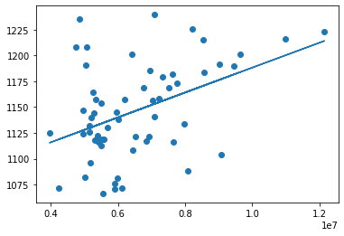

```python
y1 = (lr.coef_)*X + (lr.intercept_)
plt.scatter (X, y)
plt.plot(X, y1)
```

미국달러선물 계약금액 (백만원)

```python
X = pd.DataFrame(AmericanData['미국달러선물 계약금액 (백만원)'].values, columns = [['Contracts Amount']], dtype=float)
y = pd.DataFrame(AmericanData['원/미국달러'].values, columns = [['Exchange']], dtype=float)
AmericanCorrFuturesAmountAndExchanges = pd.concat([X, y], axis=1).corr()
print(AmericanCorrFuturesAmountAndExchanges)
```

```
                 Contracts Amount  Exchange
Contracts Amount         1.000000  0.532559
Exchange                 0.532559  1.000000
```

```python
lr = LinearRegression()
lr.fit(X, y)
print(lr.coef_) # 기울기 계수 출력
print(lr.intercept_) # 절편 출력
print(lr.score(X, y)) # 상관계수 출력
```

```
[[1.17473568e-06]]
[1058.11180207]
0.28361918900683314
```

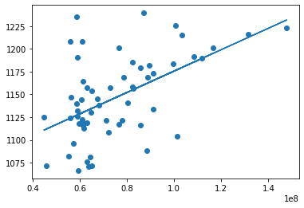

```python
y1 = (lr.coef_)*X + (lr.intercept_)
plt.scatter (X, y)
plt.plot(X, y1)
```

미국달러선물 미결제약정 (계약)

```python
X = pd.DataFrame(AmericanData['미국달러선물 미결제약정 (계약)'].values, columns = [['Open Interest Contracts']], dtype=float)
y = pd.DataFrame(AmericanData['원/미국달러'].values, columns = [['Exchange']], dtype=float)
AmericanCorrFuturesOIAndExchanges = pd.concat([X, y], axis=1).corr()
print(AmericanCorrFuturesOIAndExchanges)
```

```
                        Open Interest Contracts  Exchange
Open Interest Contracts                1.000000 -0.000303
Exchange                              -0.000303  1.000000
```

```python
lr = LinearRegression()
lr.fit(X, y)
print(lr.coef_) # 기울기 계수 출력
print(lr.intercept_) # 절편 출력
print(lr.score(X, y)) # 상관계수 출력
```

```
[[-1.32799307e-07]]
[1146.39967775]
9.168784675939179e-08
```

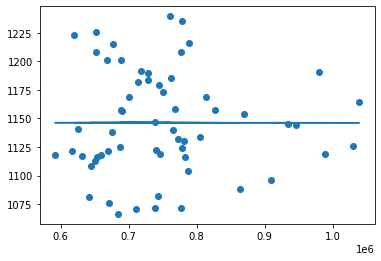

```python
y1 = (lr.coef_)*X + (lr.intercept_)
plt.scatter (X, y)
plt.plot(X, y1)
```

#### 일본 데이터 분석

일본엔에 대한 데이터 분석을 실시(과정은 미국달러 분석과 같다.)

- 엔선물 계약수 & 원/일본엔(100엔)
- 엔선물 계약금액 & 원/일본엔(100엔)
- 엔선물 미약정계약 & 원/일본엔(100엔)

엔선물 계약수 (계약)

```python
X = pd.DataFrame(JapanData['엔선물 계약수 (계약)'].values, columns = [['Contracts']], dtype=float)
y = pd.DataFrame(JapanData['원/일본엔(100엔)'].values, columns = [['Exchange']], dtype=float)
JapanCorrFuturesAndExchanges = pd.concat([X, y], axis=1).corr()
print(JapanCorrFuturesAndExchanges)
```

```
          Contracts  Exchange
Contracts  1.000000  0.105646
Exchange   0.105646  1.000000
```

```python
lr = LinearRegression()
lr.fit(X, y)
print(lr.coef_) # 기울기 계수 출력
print(lr.intercept_) # 절편 출력
print(lr.score(X, y)) # 상관계수 출력
```

```
[[0.00038752]]
[1028.1622074]
0.011161099162845356
```

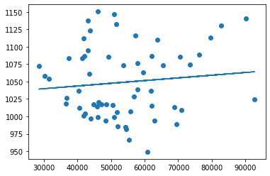

```python
y1 = (lr.coef_)*X + (lr.intercept_)
plt.scatter (X, y)
plt.plot(X, y1)
```

엔선물 계약금액 (백만원)

```python
X = pd.DataFrame(JapanData['엔선물 계약금액 (백만원)'].values, columns = [['Contracts Amount']], dtype=float)
y = pd.DataFrame(JapanData['원/일본엔(100엔)'].values, columns = [['Exchange']], dtype=float)
JapanCorrFuturesAmountAndExchanges = pd.concat([X, y], axis=1).corr()
print(JapanCorrFuturesAmountAndExchanges)
```

```
                 Contracts Amount  Exchange
Contracts Amount         1.000000  0.273776
Exchange                 0.273776  1.000000
```

```python
lr = LinearRegression()
lr.fit(X, y)
print(lr.coef_) # 기울기 계수 출력
print(lr.intercept_) # 절편 출력
print(lr.score(X, y)) # 상관계수 출력
```

```
[[9.00975529e-05]]
[998.13668442]
0.07495351298004671
```

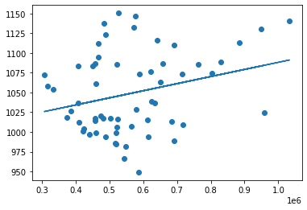

```python
y1 = (lr.coef_)*X + (lr.intercept_)
plt.scatter (X, y)
plt.plot(X, y1)
```

엔선물 미결제약정 (계약)

```python
X = pd.DataFrame(JapanData['엔선물 미결제약정 (계약)'].values, columns = [['Open Interest Contracts']], dtype=float)
y = pd.DataFrame(JapanData['원/일본엔(100엔)'].values, columns = [['Exchange']], dtype=float)
JapanCorrFuturesOIAndExchanges = pd.concat([X, y], axis=1).corr()
print(JapanCorrFuturesOIAndExchanges)
```

```
                        Open Interest Contracts  Exchange
Open Interest Contracts                1.000000  0.265742
Exchange                               0.265742  1.000000
```

```python
lr = LinearRegression()
lr.fit(X, y)
print(lr.coef_) # 기울기 계수 출력
print(lr.intercept_) # 절편 출력
print(lr.score(X, y)) # 상관계수 출력
```

```
[[0.00374101]]
[986.77417559]
0.07061861378045975
```

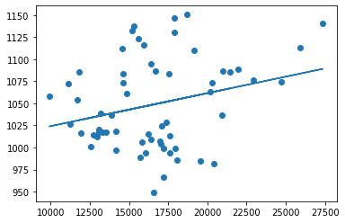

```python
y1 = (lr.coef_)*X + (lr.intercept_)
plt.scatter (X, y)
plt.plot(X, y1)
```

#### 유럽 데이터 분석

유로에 대한 데이터 분석을 실시(과정은 미국달러 분석과 같다.)

- 유로선물 계약수 & 원/유로
- 유로선물 계약금액 & 원/유로
- 유로선물 미약정계약 & 원/유로

유로선물 계약수 (계약)

```python
X = pd.DataFrame(EuroData['유로선물 계약수 (계약)'].values, columns = [['Contracts']], dtype=float)
y = pd.DataFrame(EuroData['원/유로'].values, columns = [['Exchange']], dtype=float)
EuroCorrFuturesAndExchanges = pd.concat([X, y], axis=1).corr()
print(EuroCorrFuturesAndExchanges)
```

```
          Contracts  Exchange
Contracts  1.000000  0.450255
Exchange   0.450255  1.000000
```

```python
lr = LinearRegression()
lr.fit(X, y)
print(lr.coef_) # 기울기 계수 출력
print(lr.intercept_) # 절편 출력
print(lr.score(X, y)) # 상관계수 출력
```

```
[[0.00191565]]
[1184.54714223]
0.2027296158985341
```

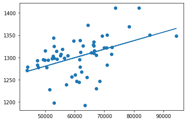

```python
y1 = (lr.coef_)*X + (lr.intercept_)
plt.scatter (X, y)
plt.plot(X, y1)
```

유로선물 계약금액 (백만원)

```python
X = pd.DataFrame(EuroData['유로선물 계약금액 (백만원)'].values, columns = [['Contracts Amount']], dtype=float)
y = pd.DataFrame(EuroData['원/유로'].values, columns = [['Exchange']], dtype=float)
EuroCorrFuturesAmountAndExchanges = pd.concat([X, y], axis=1).corr()
print(EuroCorrFuturesAmountAndExchanges)
```

```
                 Contracts Amount  Exchange
Contracts Amount         1.000000  0.572079
Exchange                 0.572079  1.000000
```

```python
lr = LinearRegression()
lr.fit(X, y)
print(lr.coef_) # 기울기 계수 출력
print(lr.intercept_) # 절편 출력
print(lr.score(X, y)) # 상관계수 출력
```

```
[[0.00016684]]
[1168.44969725]
0.3272743948674137
```

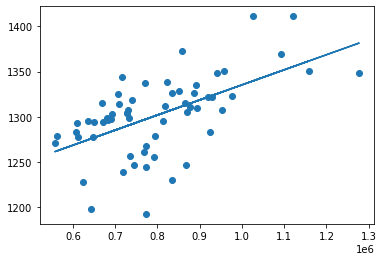

```python
y1 = (lr.coef_)*X + (lr.intercept_)
plt.scatter (X, y)
plt.plot(X, y1)
```

유로선물 미결제약정 (계약)

```python
X = pd.DataFrame(EuroData['유로선물 미결제약정 (계약)'].values, columns = [['Open Interest Contracts']], dtype=float)
y = pd.DataFrame(EuroData['원/유로'].values, columns = [['Exchange']], dtype=float)
EuroCorrFuturesOIAndExchanges = pd.concat([X, y], axis=1).corr()
print(EuroCorrFuturesOIAndExchanges)
```

```
                        Open Interest Contracts  Exchange
Open Interest Contracts                1.000000 -0.134151
Exchange                              -0.134151  1.000000
```

```python
lr = LinearRegression()
lr.fit(X, y)
print(lr.coef_) # 기울기 계수 출력
print(lr.intercept_) # 절편 출력
print(lr.score(X, y)) # 상관계수 출력
```

```
[[-0.00106455]]
[1337.99068001]
0.017996448297650014
```

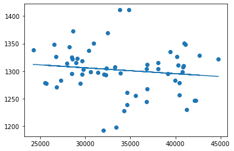

```python
y1 = (lr.coef_)*X + (lr.intercept_)
plt.scatter (X, y)
plt.plot(X, y1)
```

#### 중국 데이터 분석

중국위안에 대한 데이터 분석을 실시(과정은 미국달러 분석과 같다.)

- 위안선물 계약수 & 원/위안
- 위안선물 계약금액 & 원/위안
- 위안선물 미약정계약 & 원/위안

위안선물 계약수 (계약)

```python
X = pd.DataFrame(ChinaData['위안선물 계약수 (계약)'].values, columns = [['Contracts']], dtype=float)
y = pd.DataFrame(ChinaData['원/위안'].values, columns = [['Exchange']], dtype=float)
ChinaCorrFuturesAndExchanges = pd.concat([X, y], axis=1).corr()
print(ChinaCorrFuturesAndExchanges)
```

```
          Contracts  Exchange
Contracts  1.000000 -0.011423
Exchange  -0.011423  1.000000
```

```python
lr = LinearRegression()
lr.fit(X, y)
print(lr.coef_) # 기울기 계수 출력
print(lr.intercept_) # 절편 출력
print(lr.score(X, y)) # 상관계수 출력
```

```
[[-0.00011932]]
[169.26731524]
0.00013049166206657858
```

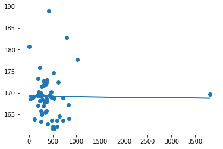

```python
y1 = (lr.coef_)*X + (lr.intercept_)
plt.scatter (X, y)
plt.plot(X, y1)
```

위안선물 계약금액 (백만원)

```python
X = pd.DataFrame(ChinaData['위안선물 계약금액 (백만원)'].values, columns = [['Contracts Amount']], dtype=float)
y = pd.DataFrame(ChinaData['원/위안'].values, columns = [['Exchange']], dtype=float)
ChinaCorrFuturesAmountAndExchanges = pd.concat([X, y], axis=1).corr()
print(ChinaCorrFuturesAmountAndExchanges)
```

```
                 Contracts Amount  Exchange
Contracts Amount         1.000000  0.015822
Exchange                 0.015822  1.000000
```

```python
lr = LinearRegression()
lr.fit(X, y)
print(lr.coef_) # 기울기 계수 출력
print(lr.intercept_) # 절편 출력
print(lr.score(X, y)) # 상관계수 출력
```

```
[[9.68875516e-06]]
[169.14138605]
0.00025033951030539736
```

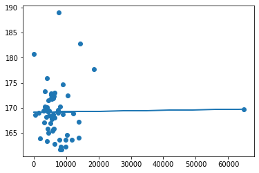

```python
y1 = (lr.coef_)*X + (lr.intercept_)
plt.scatter (X, y)
plt.plot(X, y1)
```

위안선물 미결제약정 (계약)

```python
X = pd.DataFrame(ChinaData['위안선물 미결제약정 (계약)'].values, columns = [['Open Interest Contracts']], dtype=float)
y = pd.DataFrame(ChinaData['원/위안'].values, columns = [['Exchange']], dtype=float)
ChinaCorrFuturesOIAndExchanges = pd.concat([X, y], axis=1).corr()
print(ChinaCorrFuturesOIAndExchanges)
```

```
                        Open Interest Contracts  Exchange
Open Interest Contracts                1.000000 -0.382908
Exchange                              -0.382908  1.000000
```

```python
lr = LinearRegression()
lr.fit(X, y)
print(lr.coef_) # 기울기 계수 출력
print(lr.intercept_) # 절편 출력
print(lr.score(X, y)) # 상관계수 출력
```

```
[[-0.03310312]]
[172.28133765]
0.14661841255337993
```

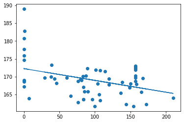

```python
y1 = (lr.coef_)*X + (lr.intercept_)
plt.scatter (X, y)
plt.plot(X, y1)
```

### 다중회귀분석 및 Test

선형회귀분석으로 높은 상관관계를 얻지 못함. 통화선물을 계약수, 계약금액, 미체결계약으로 나누어 선형회귀분석을 실시하여 나타낸 결과로 판단.

통화선물의 데이터는 3가지로 나뉘는 것이 아닌 3가지가 모여야 하나의 데이터가 됨. 따라서 다중회귀분석을 진행, 이 역시 국가, 즉 통화별로 구분하여 확인

- 미국
- 일본
- 유럽
- 중국

#### 미국 데이터 다중회기분석 및 테스트

다중회귀분석하는 과정

```python
X = AmericanData.iloc[:,1:]
y = pd.DataFrame(AmericanData['원/미국달러'].values, columns = [['Exchange']], dtype=float)
lr2 = LinearRegression()
lr2.fit(X, y)
print(lr2.coef_) # 기울기 계수 출력
print(lr2.intercept_) # 절편 출력
print(lr2.score(X, y)) # 상관계수 출력
```

```
[[-1.72657040e-04  1.48810389e-05  1.94510322e-05]]
[1139.98713361]
0.8726104017469026
```

```python
print('분석 데이터\n', lr2.predict(AmericanData_Test.iloc[:,1:]))
print('실제 데이터\n', AmericanData_Test.iloc[:,:1])
```

```
분석 데이터
 [[1076.11940773]
 [1104.15307589]
 [1120.66372977]
 [1107.67874642]
 [1117.84606548]
 [1111.94223309]]
실제 데이터
          원/미국달러
날짜
2021-01  1114.6
2021-02  1108.4
2021-03  1133.5
2021-04  1107.4
2021-05  1116.0
2021-06  1130.0
```

#### 일본 데이터 다중회기분석

```python
X = JapanData.iloc[:,1:]
y = pd.DataFrame(JapanData['원/일본엔(100엔)'].values, columns = [['Exchange']], dtype=float)
lr2 = LinearRegression()
lr2.fit(X, y)
print(lr2.coef_) # 기울기 계수 출력
print(lr2.intercept_) # 절편 출력
print(lr2.score(X, y)) # 상관계수 출력
```

```
[[-0.01725351  0.00160194  0.00052733]]
[1061.79008329]
0.8457023835486454
```

```python
print('분석 데이터\n', lr2.predict(JapanData_Test.iloc[:,1:]))
print('실제 데이터\n', JapanData_Test.iloc[:,:1])
```

```
분석 데이터
 [[1058.32098679]
 [1060.10640552]
 [1052.24764506]
 [1046.93204289]
 [1049.20278349]
 [1043.84509932]]
실제 데이터
          원/일본엔(100엔)
날짜
2021-01      1069.26
2021-02      1043.15
2021-03      1027.33
2021-04      1016.90
2021-05      1015.70
2021-06      1022.12
```

#### 유럽 데이터 다중회기분석

```python
X = EuroData.iloc[:,1:]
y = pd.DataFrame(EuroData['원/유로'].values, columns = [['Exchange']], dtype=float)
lr2 = LinearRegression()
lr2.fit(X, y)
print(lr2.coef_) # 기울기 계수 출력
print(lr2.intercept_) # 절편 출력
print(lr2.score(X, y)) # 상관계수 출력
```

```
[[-1.81292321e-02  1.39268111e-03  1.31082263e-05]]
[1297.75858818]
0.8130268157472679
```

```python
print('분석 데이터\n', lr2.predict(EuroData_Test.iloc[:,1:]))
print('실제 데이터\n', EuroData_Test.iloc[:,:1])
```

```
분석 데이터
 [[1328.25078489]
 [1338.13082331]
 [1343.64536219]
 [1329.83227939]
 [1356.40839483]
 [1346.98463628]]
실제 데이터
             원/유로
날짜
2021-01  1351.12
2021-02  1349.86
2021-03  1328.29
2021-04  1342.33
2021-05  1360.91
2021-06  1344.42
```

#### 중국 데이터 다중회기분석

```python
X = ChinaData.iloc[:,1:]
y = pd.DataFrame(ChinaData['원/위안'].values, columns = [['Exchange']], dtype=float)
lr2 = LinearRegression()
lr2.fit(X, y)
print(lr2.coef_) # 기울기 계수 출력
print(lr2.intercept_) # 절편 출력
print(lr2.score(X, y)) # 상관계수 출력
```

```
[[-0.23390125  0.0137209  -0.0055535 ]]
[170.28712258]
0.6349312107764751
```

```python
print('분석 데이터\n', lr2.predict(ChinaData_Test.iloc[:,1:]))
print('실제 데이터\n', ChinaData_Test.iloc[:,:1])
```

```
분석 데이터
 [[169.34420951]
 [170.08281427]
 [170.96650556]
 [169.67867839]
 [171.41057224]
 [171.27917081]]
실제 데이터
            원/위안
날짜
2021-01  171.45
2021-02  171.86
2021-03  172.35
2021-04  171.20
2021-05  175.22
2021-06  174.84
```